```python
import numpy as np
import matplotlib.pyplot as plt
import random
import pandas as pd
```

# Question 1 (10 marks)

```python
class People:
    def __init__(self,xpos,ypos,state):
        self.xpos = xpos
        self.ypos = ypos
        self.state = state
```

```python
def locs_where(condition):
    return list(zip(*np.nonzero(condition)))
```

```python
class Virus():
    maxtime = 1000
    def __init__(self,recovery_rt=0,sidelength = 40,npeople = 100):
        self.sidelength = sidelength
        self.npeople = npeople
        self.recovery_rt = recovery_rt
        self.healthy = 99
        self.infected = 1
        self.recovered = 0

        arr = np.array([0]*(sidelength**2-self.npeople)+[1]*self.healthy+[2]*self.infected)
        np.random.shuffle(arr)
        self.array = np.reshape(arr,(sidelength,sidelength))
        people = self.array!=0

        self.people = []
        people_loc = locs_where(people)
        for l in people_loc:
            xpos = l[1]
            ypos = l[0]
            state = self.array[ypos][xpos]
            self.people.append(People(xpos,ypos,state))
        self.infect_history=1

    def move(self,people):
        x = people.xpos
        y = people.ypos
        y_next = random.choice([y-1,y,y+1])
        x_next = random.choice([x-1,x,x+1])

        if y_next<0:
            y_next = self.sidelength-1
        elif y_next>self.sidelength-1:
            y_next = 0

        if x_next<0:
            x_next = self.sidelength-1
        elif x_next>self.sidelength-1:
            x_next = 0

        people.xpos = x_next
        people.ypos = y_next
    def step(self):
        for people in self.people:
            self.move(people)

    def update(self):#mean to update the state of people
        self.inf_loc = []

        for people in self.people:
            if people.state == 2:
                people.state=np.random.choice([3,2],p = [self.recovery_rt,1-self.recovery_rt])
                if people.state == 3:
                    self.recovered += 1
                    self.infected -=1

        for people in self.people:
            if people.state == 2 and (people.ypos,people.xpos) not in self.inf_loc:
                self.inf_loc.append((people.ypos,people.xpos))


        for people in self.people:
            if (people.ypos,people.xpos) in self.inf_loc and people.state == 1:
                people.state = 2
                self.infected+=1
                self.healthy-=1
                self.infect_history+=1


    def time(self): #calculate the time of last ppl get infected
        self.i = 0
        self.inf = []
        self.heal = []
        self.recov = []
        t = self.maxtime
        while self.i<=t:
            self.i+=1
            self.step()
            self.update()
            self.inf.append(self.infected)
            self.heal.append(self.healthy)
            self.recov.append(self.recovered)
            if self.infected==0 or self.infected == 100:
                break
        return self.i


    def plot(self):
        self.time()
        if self.recovery_rt == 0:
            plt.plot(np.arange(0,self.i),self.inf)
            plt.show()
        else:
            plt.plot(np.arange(0,self.i),self.inf,label = 'infected')
            plt.plot(np.arange(0,self.i),self.heal,label = 'healthy')
            plt.plot(np.arange(0,self.i),self.recov,label = 'recovered')
            plt.legend()
            plt.show()
```

When there is no revovery rate:

```python
world = Virus()
```

1. initial condition

```python
x1 = []
y1 = []
x2 = []
y2 = []
x3 = []
y3 = []
for people in world.people:
    if people.state == 1:
        x1.append(people.xpos)
        y1.append(people.ypos)
    elif people.state == 2:
        x2.append(people.xpos)
        y2.append(people.ypos)
    else:
        x3.append(people.xpos)
        y3.append(people.ypos)
```

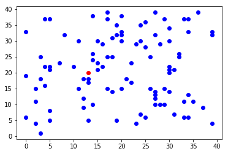

```python
plt.scatter(x1,y1,c = 'blue')
plt.scatter(x2,y2,c = 'red')
plt.show()
```

1. Last people being infected:

```python
world.time()
```

```
340
```

```python
x1 = []
y1 = []
x2 = []
y2 = []
x3 = []
y3 = []
for people in world.people:
    if people.state == 1:
        x1.append(people.xpos)
        y1.append(people.ypos)
    elif people.state == 2:
        x2.append(people.xpos)
        y2.append(people.ypos)
    else:
        x3.append(people.xpos)
        y3.append(people.ypos)
```

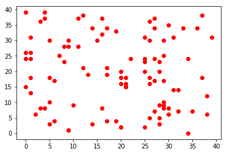

```python
plt.scatter(x1,y1,c = 'blue')
plt.scatter(x2,y2,c = 'red')
plt.show()
```

When there is recovery (recovery rate = 0.01):

```python
rworld = Virus(recovery_rt = 0.01)
```

1. On the 200 day:

```python
t = 0
while t<200:
    rworld.step()
    rworld.update()
    t+=1
```

```python
x1 = []
y1 = []
x2 = []
y2 = []
x3 = []
y3 = []
for people in rworld.people:
    if people.state == 1:
        x1.append(people.xpos)
        y1.append(people.ypos)
    elif people.state == 2:
        x2.append(people.xpos)
        y2.append(people.ypos)
    else:
        x3.append(people.xpos)
        y3.append(people.ypos)
```

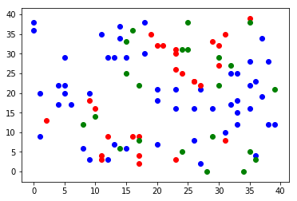

```python
plt.scatter(x1,y1,c = 'blue')
plt.scatter(x2,y2,c = 'red')
plt.scatter(x3,y3,c = 'green')
###label
plt.show()
```

1. On the last day:

```python
rworld = Virus(recovery_rt = 0.01)
rworld.time()
```

```
723
```

```python
x1 = []
y1 = []
x2 = []
y2 = []
x3 = []
y3 = []
for people in rworld.people:
    if people.state == 1:
        x1.append(people.xpos)
        y1.append(people.ypos)
    elif people.state == 2:
        x2.append(people.xpos)
        y2.append(people.ypos)
    else:
        x3.append(people.xpos)
        y3.append(people.ypos)
```

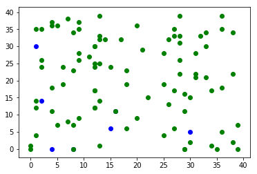

```python
plt.scatter(x1,y1,c = 'blue')
plt.scatter(x2,y2,c = 'red')
plt.scatter(x3,y3,c = 'green')
###label
plt.show()
```

(1.1) If there is no recovery, what is the average length of time until the last person gets infected? Provide also an estimate of the uncertainty in your value.

```python
time = np.zeros(100)
for i in range(100):
    test = Virus()
    time[i] = test.time()
```

```python
print('average:',np.mean(time))
```

```
average: 292.11
```

```python
print('standard error:',np.std(time)/np.sqrt(100))
```

```
standard error: 4.46396449358639
```

(1.2) Averaging over many runs: Plot the number of infected people as a function of time.

```python
t = 350
niters=100
infect_overtime = np.zeros([niters,t])
for j in range(niters):
    inf = []
    i = 0
    test = Virus()
    while i<=t:
        test.step()
        test.update()
        i+=1
        inf.append(test.infected)

    infect_overtime[j]=inf[:t]
```

```python
mean_infect = np.sum(infect_overtime,axis = 0)/len(infect_overtime)
```

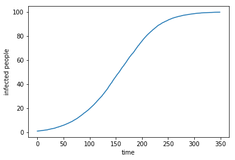

```python
plt.plot(np.arange(0,t),mean_infect)
plt.xlabel('time')
plt.ylabel('infected people')
plt.show()
```

(1.3) If you halve the size of the world (i.e., set sidelength=20), how does this change the time it takes until the last person is infected? Briefly discuss the real-world implications of this result.

```python
test1 = Virus(sidelength = 20)
print(test1.time())
```

```
64
```

If the space narrows down, meaning that the chance for a healthy people be in the same place with an infected people would increase, indicating that the time it takes until the last person is infected would be shorten a lot.

(1.4) Now let’s allow people to recover. Using the original size of the world (sidelength=40), change the recovery rate from 0 to 0.01 (i.e., every 100 days on average an infected person will spontaneously recover). Run the experiment a few times and then describe qualitatively what you observe. Do these results look realistic? For a representative case plot the number of infected people, the number of healthy people, and the number of recovered people versus time on the same set of axes.

```python
inf = np.zeros(5)
time = np.zeros(5)
for i in range(5):
    test = Virus(recovery_rt = 0.01)
    test.time()
    time[i] = test.i
    inf[i] = test.infected
```

```python
print(time)
print(np.mean(time))
print(inf)
```

```
[769.   7. 715. 585. 881.]
591.4
[0. 0. 0. 0. 0.]
```

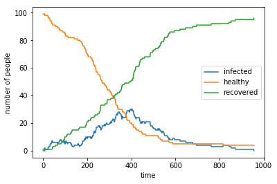

```python
test = Virus(recovery_rt = 0.01)
plt.xlabel('time')
plt.ylabel('number of people')
test.plot()
```

1. The number of infected people firstly goes up, peaking in between 200 and 400, then goes down.
2. There is a chance that not everyone would be infected.
3. The recovery rate has significantly decreased the probability for healthy people from being infected.
4. This doesn't seem to be quite realistic,

   ```
    i)since with the recovery rate equals to 0.01, it should be on average there is 1 people recovered in 100 days. However,in  my model it looks my actual recovery rate is far higher than the 0.01 and higher than real world cases as well
    ii) the real world cases should be more complex, there still might be a chance for recovered people got infected again.
   ```

(1.5) Let’s now explore the effect of social distancing measures. We could do this by changing the size of the grid dynamically, or changing how quickly people move (reducing the chance of interaction), but an easier way is to simply change the recovery rate. If we increase the recovery rate then this is similar to making the grid larger (or have people move more slowly) as the key parameter is the R0, the number of people each infected person infects. This number will go down on average if the infected people recover before they get a chance to infect many people. By running a number of experiments determine the average infection peak fraction as a function of the recovery parameter. Plot also the average total fraction who end up being infected as a function of the recovery parameter. Comment on your findings with respect to the idea of ‘flattening the curve’.

```python
recovery_rt = np.linspace(0,0.2,50)

frac = np.zeros([len(recovery_rt),50])
inf = np.zeros([len(recovery_rt),50])
m=0
for r in recovery_rt:
    for i in range(50):
        test = Virus(recovery_rt = r)
        test.time()
        inf[m][i] = test.infect_history/100
        frac[m][i] = max(test.inf)/100
    m+=1
```

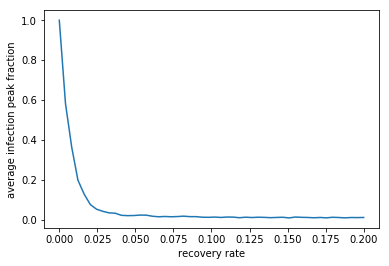

```python
plt.plot(recovery_rt,np.sum(frac,axis = 1)/50)
plt.xlabel('recovery rate')
plt.ylabel('average infection peak fraction')
plt.show()
```

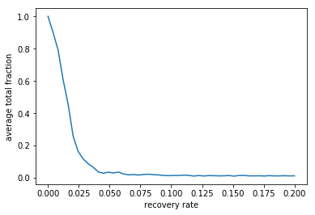

```python
plt.plot(recovery_rt,np.sum(inf,axis = 1)/50)
plt.xlabel('recovery rate')
plt.ylabel('average total fraction')
plt.show()
```

It seems that taking social distancing measures can effectively reduce peak number of cases and reduce the level of overall cases, which can flattening the curve of daily number of cases.

# Question 2 (10 marks)

```python
#on average the buses are 10 minutes apart
class M1():
    def __init__(self,N):
        self.n = N #N buses
        self.pn = 10*N #passenger numbers
        self.time = 10*N #T_n
        self.arrival_gap = np.random.exponential(10,N-1)
        self.arrival = np.zeros(N)
        for i in range(N-1):
            self.arrival[i+1] = self.arrival[i]+self.arrival_gap[i]
        self.arrival[self.arrival>self.time] = self.time
        self.arrival[self.arrival<0] = 0
        self.passenger = sorted(np.random.uniform(0,self.arrival[-1],self.pn))


    def ppl_on_bus(self):
        self.bus = {}
        for i in range(self.n-1):
            self.bus[self.arrival[i+1]] = []
            for p in self.passenger:
                if p < self.arrival[i+1] and p> self.arrival[i]:
                    self.bus[self.arrival[i+1]].append(p)

    def wait(self):
        self.ppl_on_bus()

        self.waitime = {}
        wait_list = []
        for k,v in self.bus.items():
            self.waitime[k] = []
            for i in range(len(v)):
                wait = k-v[i]
                self.waitime[k].append(wait)
                wait_list.append(wait)
        return np.mean(wait_list)
```

```python
class M2:
    def __init__(self,N,x):
        self.n = N #N buses
        self.pn = 10*N #passenger numbers
        self.time = 10*N #T_n
        self.arri = np.arange(1,self.time,10)
        for i in range(N):
            self.arri[i] = self.arri[i]+np.random.uniform(-x,x)
        self.arrival = sorted(self.arri)
        self.passenger = sorted(np.random.uniform(0,self.arrival[-1],self.pn))

    def ppl_on_bus(self):
        self.bus = {}
        for i in range(self.n-1):
            self.bus[self.arrival[i+1]] = []
            for p in self.passenger:
                if p < self.arrival[i+1] and p> self.arrival[i]:
                    self.bus[self.arrival[i+1]].append(p)

    def wait(self):
        self.ppl_on_bus()
        self.waitime = {}
        wait_list = []
        for k,v in self.bus.items():
            self.waitime[k] = []
            for i in range(len(v)):
                wait = k-v[i]
                self.waitime[k].append(wait)
                wait_list.append(wait)
        return np.mean(wait_list)
```

```python
class M3:
    def __init__(self,N,sig):
        self.n = N #N buses
        self.pn = 10*N #passenger numbers
        self.time = 10*N #T_n
        self.arri = np.arange(0,self.time+1,10)
        for i in range(N):
            self.arri[i] = self.arri[i]+np.random.normal(0,sig)
        self.arrival = sorted(self.arri)
        self.passenger = sorted(np.random.uniform(0,self.arrival[-1],self.pn))

    def ppl_on_bus(self):
        self.bus = {}
        for i in range(self.n-1):
            self.bus[self.arrival[i+1]] = []
            for p in self.passenger:
                if p < self.arrival[i+1] and p> self.arrival[i]:
                    self.bus[self.arrival[i+1]].append(p)
    def wait(self):
        self.ppl_on_bus()

        self.waitime = {}
        wait_list = []
        for k,v in self.bus.items():
            self.waitime[k] = []
            for i in range(len(v)):
                wait = k-v[i]
                self.waitime[k].append(wait)
                wait_list.append(wait)
        return np.mean(wait_list)
```

(2.1) For each Model carry out the following (for Model 2, take 𝑥=5 , and for Model 3, take 𝜎=4 ):

1. Confirm that the average interval between buses in each case is 10 minutes;
2. Determine the average waiting time for people;
3. Plot a histogram of the interval between bus arrivals;
4. Identify the nature of the distribution of bus intervals for each model.

```python
N = 500
```

##### Model 1

```python
model1 = M1(N)
gap1 = model1.arrival_gap
print(np.mean(gap1))
```

```
10.866929503606777
```

```python
print(model1.wait())
```

```
10.406564797747105
```

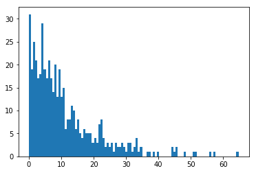

```python
plt.hist(gap1,bins = 100)
plt.show()
```

Exponential distribution

##### Model 2

```python
x = 5
model2 = M2(N,x)
gap2 = []
for i in range(len(model2.arrival)-1):
    g =model2.arrival[i+1]-model2.arrival[i]
    gap2.append(g)
print(np.mean(gap2))
```

```
10.004008016032063
```

```python
print(model2.wait())
```

```
5.7664205773889
```

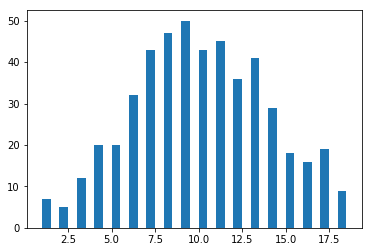

```python
plt.hist(gap2,bins = np.arange(min(gap2),max(gap2),0.5))
plt.show()
```

Triangular distribution.

##### Model 3

```python
sig = 4
model3 = M3(N,sig)
gap3 = []
for i in range(len(model3.arrival)-1):
    g =model3.arrival[i+1]-model3.arrival[i]
    gap3.append(g)
print(np.mean(gap3))
```

```
10.0
```

```python
print(model3.wait())
```

```
6.347756537914441
```

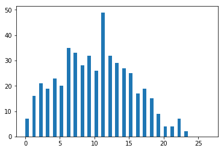

```python
plt.hist(gap3,bins = np.arange(min(gap3),max(gap3),0.5))
plt.show()
```

It should be like normal distribution. However, since time gap between buses should be positive, the left tail has been cut at zero.

(2.2) How does the estimate of average wait time depend on 𝑥 (for Model 2) and 𝜎 (for Model 3)? A short explanation of the main observations is sufficient. How do the distributions of bus intervals change with these parameters (again a short paragraph of the main observations is sufficient).

##### Model 2

```python
X= np.arange(0,10)
avg_wait1 = []
for x in X:
    model = M2(N,x)
    avg_wait1.append(model.wait())
```

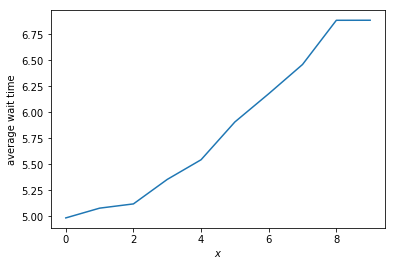

```python
plt.plot(X,avg_wait1)
plt.xlabel('$x$')
plt.ylabel('average wait time')
plt.show()
```

The average wait time increases as x increases.

##### Model 3

```python
X= np.arange(0,10)
avg_wait2 = []
for x in X:
    model = M3(N,x)
    avg_wait2.append(model.wait())
```

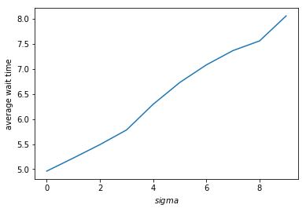

```python
plt.plot(X,avg_wait2)
plt.xlabel('$sigma$')
plt.ylabel('average wait time')
plt.show()
```

The average wait time increases as sigma increases.

##### distributions of bus intervals

```python
X= np.arange(2,12,2)

gap = np.zeros([len(X),N-1])
for j in range(5):
#     for x in X:
    model = M2(N,X[j])
    gg = []
    for i in range(len(model.arrival)-1):
        g =model.arrival[i+1]-model.arrival[i]
        gg.append(g)
    gap[j][:len(gg)] = gg
```

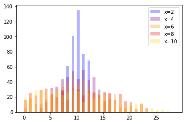

```python
[y,x,patches] = plt.hist(gap[0],bins = np.arange(min(gap[0]),max(gap[0]),0.5),color = 'blue',alpha = 0.3,label = 'x=2')
[y1,x1,patches] = plt.hist(gap[1],bins = np.arange(min(gap[1]),max(gap[1]),0.5),color = 'purple',alpha = 0.3,label = 'x=4')
[y2,x2,patches] = plt.hist(gap[2],bins = np.arange(min(gap[2]),max(gap[2]),0.5),color = 'darkorange',alpha = 0.3,label = 'x=6')
[y3,x3,patches] = plt.hist(gap[3],bins = np.arange(min(gap[3]),max(gap[3]),0.5),color = 'red',alpha = 0.3,label = 'x=8')
[y4,x4,patches] = plt.hist(gap[4],bins = np.arange(min(gap[4]),max(gap[4]),0.5),color = 'gold',alpha = 0.3,label = 'x=10')
plt.legend()
plt.show()
```

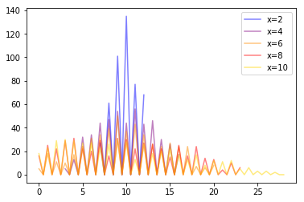

```python
plt.plot(x[:-1],y,color = 'blue',alpha = 0.5,label = 'x=2')
plt.plot(x1[:-1],y1,color = 'purple',alpha = 0.5,label = 'x=4')
plt.plot(x2[:-1],y2,color = 'darkorange',alpha = 0.5,label = 'x=6')
plt.plot(x3[:-1],y3,color = 'red',alpha = 0.5,label = 'x=8')
plt.plot(x4[:-1],y4,color = 'gold',alpha = 0.5,label = 'x=10')
plt.legend()
plt.show()
```

It seems that the higher the x value, the wider the distribution of bus intervals will be.

##### Model 3

```python
sig= np.arange(2,12,2)
gap1 = np.zeros([len(sig),N-1])
for j in range(5):
#     for x in X:
    model = M3(N,sig[j])
    gg = []
    for i in range(len(model.arrival)-1):
        g =model.arrival[i+1]-model.arrival[i]
        gg.append(g)
    gap1[j] = gg[:len(gap1[j])]
```

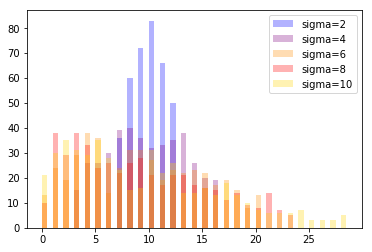

```python
[y,x,patches] = plt.hist(gap1[0],bins = np.arange(min(gap[0]),max(gap[0]),0.5),color = 'blue',alpha = 0.3,label = 'sigma=2')
[y1,x1,patches] = plt.hist(gap1[1],bins = np.arange(min(gap[1]),max(gap[1]),0.5),color = 'purple',alpha = 0.3,label = 'sigma=4')
[y2,x2,patches] = plt.hist(gap1[2],bins = np.arange(min(gap[2]),max(gap[2]),0.5),color = 'darkorange',alpha = 0.3,label = 'sigma=6')
[y3,x3,patches] = plt.hist(gap1[3],bins = np.arange(min(gap[3]),max(gap[3]),0.5),color = 'red',alpha = 0.3,label = 'sigma=8')
[y4,x4,patches] = plt.hist(gap1[4],bins = np.arange(min(gap[4]),max(gap[4]),0.5),color = 'gold',alpha = 0.3,label = 'sigma=10')
plt.legend()
plt.show()
```

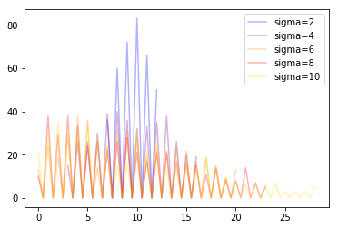

```python
plt.plot(x[:-1],y,color = 'blue',alpha = 0.3,label = 'sigma=2')
plt.plot(x1[:-1],y1,color = 'purple',alpha = 0.3,label = 'sigma=4')
plt.plot(x2[:-1],y2,color = 'darkorange',alpha = 0.3,label = 'sigma=6')
plt.plot(x3[:-1],y3,color = 'red',alpha = 0.3,label = 'sigma=8')
plt.plot(x4[:-1],y4,color = 'gold',alpha = 0.3,label = 'sigma=10')
plt.legend()
plt.show()
```

As sigma increases, the wider the distribution of bus intervals will be.

(2.3) Real-world bus data is available on Canvas, “Route 1 minutes late.csv” and “Route 2 minutes late.csv”. These files contain a list of times for buses compared to their scheduled arrival times. A negative number means the bus was early.

(i) Read in the data and plot histograms of the minutes late for each route;

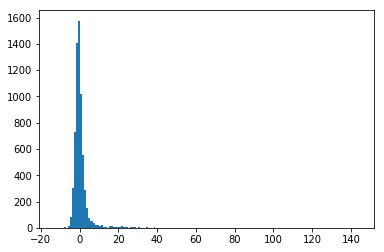

```python
r1 = pd.read_csv("Route_1_minutes_late.csv",names=['minutes_late'])
r1 = r1['minutes_late'].values
plt.hist(r1,bins=np.arange(min(r1),max(r1),1))
plt.show()
```

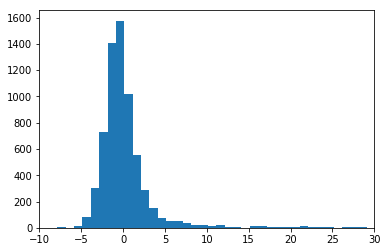

```python
plt.hist(r1,bins=np.arange(min(r1),max(r1),1))
plt.xlim(-10,30)
plt.show()
```

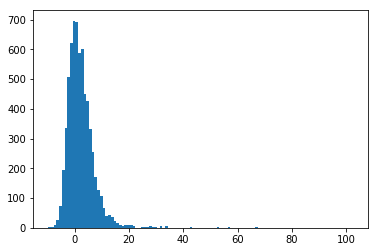

```python
r2 = pd.read_csv("Route_2_minutes_late.csv",names=['minutes_late'])
r2 = r2['minutes_late'].values
plt.hist(r2,bins=np.arange(min(r2),max(r2),1))
plt.show()
```

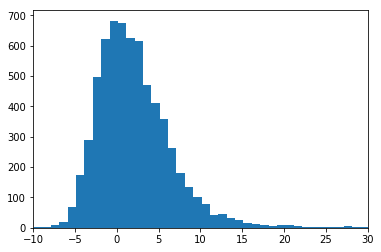

```python
plt.hist(r2,bins=np.arange(min(r1),max(r1),1))
plt.xlim(-10,30)
plt.show()
```

(ii) Compare the data to predictions from your simulations. Which model seems to be the best fit for the real-world data?

```python
# convert lateness to bus intervals
arrival1 = r1+ np.arange(10,10*len(r1)+1,10)
arrival1 = sorted(arrival1)
interval1 = np.zeros(len(r1)-1)
for i in range(len(r1-1)-1):
    interval1[i] = arrival1[i+1]-arrival1[i]
```

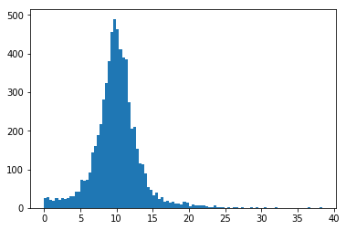

```python
plt.hist(interval1,bins = 100)
plt.show()
```

```python
arrival2 = r2+ np.arange(10,10*len(r2)+1,10)
arrival2 = sorted(arrival2)
interval2 = np.zeros(len(r2)-1)
for i in range(len(r2-1)-1):
    interval2[i] = arrival2[i+1]-arrival2[i]
```

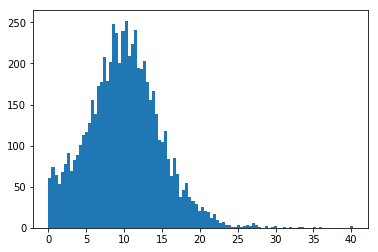

```python
plt.hist(interval2,bins = 100)
plt.show()
```

The distribution of bus intervals for both routes look like right skewed normal distribution.However, the tail for route2 looks fatter than rout1. Therefore, for both route1 and route2 , model 3 is the better fit, but route 1 should have a smaller sigma value.

(2.4) What can you conclude about the wait time for passengers? From the timetable, it is expected to be 5 minutes. From your simulations, and comparison with real-world data, is this reasonable, or can we expect a different wait time? A comment with reference (i.e. supported by) your earlier results is sufficient.

```python
print(np.sum(r1>20)/len(r1))
print(max(r1))
print(np.mean(r1))
```

```
0.012669821401312776
144.71666666666667
0.41279702844349475
```

```python
print(np.sum(r2>20)/len(r2))
print(max(r2))
print(np.mean(r2))
```

```
0.011610143599144515
102.48333333333332
2.4123179549852325
```